# Tugas Kuliah 3

Tri Ananda Marpaung | M0401241098

# Soal Nomor 1

```r
data <- rio::import("C:/Users/Dewi Lestari Natalia/Downloads/Data_Latihan_Distributed_Lag.xlsx")
str(data)
```

```
## 'data.frame':    20 obs. of  3 variables:
##  $ Period        : num  1 2 3 4 5 6 7 8 9 10 ...
##  $ Market_share_Y: num  3.63 4.2 3.33 4.54 2.89 4.87 4.9 5.29 6.18 7.2 ...
##  $ Price_X       : num  0.97 0.95 0.99 0.91 0.98 0.9 0.89 0.86 0.85 0.82 ...
```

```r
data
```

```
##    Period Market_share_Y Price_X
## 1       1           3.63    0.97
## 2       2           4.20    0.95
## 3       3           3.33    0.99
## 4       4           4.54    0.91
## 5       5           2.89    0.98
## 6       6           4.87    0.90
## 7       7           4.90    0.89
## 8       8           5.29    0.86
## 9       9           6.18    0.85
## 10     10           7.20    0.82
## 11     11           7.25    0.79
## 12     12           6.09    0.83
## 13     13           6.80    0.81
## 14     14           8.65    0.77
## 15     15           8.43    0.76
## 16     16           8.29    0.80
## 17     17           7.18    0.83
## 18     18           7.90    0.79
## 19     19           8.45    0.76
## 20     20           8.23    0.78
```

```r
head(data)
```

```
##   Period Market_share_Y Price_X
## 1      1           3.63    0.97
## 2      2           4.20    0.95
## 3      3           3.33    0.99
## 4      4           4.54    0.91
## 5      5           2.89    0.98
## 6      6           4.87    0.90
```

```r
names(data)
```

```
## [1] "Period"         "Market_share_Y" "Price_X"
```

```r
data <- data.frame(
  Yt = data$Market_share_Y,
  Xt = data$Price_X
)
```

```r
train <- data[1:15, ]
test <- data[16:20, ]
```

```r
library(dLagM)
```

```r
library(ggplot2)
```

# Model Koyck

Model Koyck digunakan untuk pengaruh variabel bebas yang tidak hanya terjadi pada periode sekarang, tetapi juga menyebar ke periode berikutnya dengan pola yang menurun.

```r
model.koyck <- koyckDlm(
  x = train$Xt,
  y = train$Yt
)

summary(model.koyck)
```

```
##
## Call:
## "Y ~ (Intercept) + Y.1 + X.t"
##
## Residuals:
##     Min      1Q  Median      3Q     Max
## -0.9997 -0.3171  0.0652  0.2586  1.1063
##
## Coefficients:
##             Estimate Std. Error t value Pr(>|t|)
## (Intercept)  15.4328    14.7611   1.046    0.318
## Y.1           0.3651     0.5152   0.709    0.493
## X.t         -13.4703    13.8869  -0.970    0.353
##
## Residual standard error: 0.599 on 11 degrees of freedom
## Multiple R-Squared: 0.9037,  Adjusted R-squared: 0.8861
## Wald test: 37.92 on 2 and 11 DF,  p-value: 1.16e-05
##
## Diagnostic tests:
## NULL
##
##                             alpha      beta       phi
## Geometric coefficients:  24.30938 -13.47028 0.3651498
```

# Forecast

```r
fore.koyck <- dLagM::forecast(
  model = model.koyck,
  x = test$Xt,
  h = 5
)

fore.koyck
```

```
## $forecasts
## [1] 7.734805 7.076847 7.375405 7.888531 7.806494
##
## $call
## forecast.koyckDlm(model = model.koyck, x = test$Xt, h = 5)
##
## attr(,"class")
## [1] "forecast.koyckDlm" "dLagM"
```

Hasil estimasi model Koyck menunjukkan: * Intercept = 15.4328 * Yt-1 = 0.3651 * Xt = -13.4703 * Adjusted R^2 = 0.8861 * Wald test p-value = 1.16 x 10^-5

Koefisien Yt-1 sebesar 0.3651 menunjukkan adanya penagruh nilai varibael dependen sebelumnya terhadap periode sekarang. Nilai parameter tersebut juga menunjukkan adanya pola persistensi dalam model.

Namun, secara individual koefisien Yt-1 dan Xt memiliki p-value masing-masing 0.493 dan 0.353 sehingga tidak signifikan pada taraf 5%.

Meskipun demikian, uji Wald secara keseluruhsn signifikan, sehingga model masih memiliki hubungan secara simultan.

# DLM

```r
model.dlm <- dLagM::dlm(
  x = train$Xt,
  y = train$Yt,
  q = 3
)

summary(model.dlm)
```

```
##
## Call:
## lm(formula = model.formula, data = design)
##
## Residuals:
##      Min       1Q   Median       3Q      Max
## -0.35052 -0.24953  0.02349  0.19872  0.45187
##
## Coefficients:
##             Estimate Std. Error t value Pr(>|t|)
## (Intercept)   27.975      1.502  18.620  3.2e-07 ***
## x.t          -27.521      3.935  -6.993 0.000213 ***
## x.1            3.765      3.328   1.131 0.295228
## x.2            2.805      3.518   0.797 0.451514
## x.3           -4.800      3.486  -1.377 0.210928
## ---
## Signif. codes:  0 '***' 0.001 '**' 0.01 '*' 0.05 '.' 0.1 ' ' 1
##
## Residual standard error: 0.3504 on 7 degrees of freedom
## Multiple R-squared:  0.9725, Adjusted R-squared:  0.9569
## F-statistic: 61.99 on 4 and 7 DF,  p-value: 1.511e-05
##
## AIC and BIC values for the model:
##       AIC      BIC
## 1 14.4199 17.32934
```

```r
fore.dlm <- dLagM::forecast(
  model = model.dlm,
  x = test$Xt,
  h = 5
)

fore.dlm
```

```
## $forecasts
## [1] 7.091237 6.580171 7.954150 8.521314 7.601750
##
## $call
## forecast.dlm(model = model.dlm, x = test$Xt, h = 5)
##
## attr(,"class")
## [1] "forecast.dlm" "dLagM"
```

Model DLM(3) memasukkan pengaruh variabel bebas sampai 3 lag.

Hasil estimasi menunjukkan:

Intercept = 27.975 $X_t=-27.521$ $X_{t-1}=3.765$ $X_{t-2}=2.805$ $X_{t-3}=-4.800$

```r
model.ardl <- dLagM::ardlDlm(
  x = train$Xt,
  y = train$Yt,
  p = 1,
  q = 1
)

summary(model.ardl)
```

```
##
## Time series regression with "ts" data:
## Start = 2, End = 15
##
## Call:
## dynlm(formula = as.formula(model.text), data = data, start = 1)
##
## Residuals:
##      Min       1Q   Median       3Q      Max
## -0.50247 -0.30360 -0.05952  0.31335  0.74004
##
## Coefficients:
##             Estimate Std. Error t value Pr(>|t|)
## (Intercept)  18.1366     7.7391   2.344   0.0411 *
## X.t         -23.5593     2.8404  -8.294 8.57e-06 ***
## X.1           7.2280     7.2307   1.000   0.3411
## Y.1           0.3028     0.3013   1.005   0.3386
## ---
## Signif. codes:  0 '***' 0.001 '**' 0.01 '*' 0.05 '.' 0.1 ' ' 1
##
## Residual standard error: 0.4177 on 10 degrees of freedom
## Multiple R-squared:  0.9574, Adjusted R-squared:  0.9446
## F-statistic: 74.91 on 3 and 10 DF,  p-value: 3.731e-07
```

```r
class(model.ardl)
```

```
## [1] "ardlDlm" "dLagM"
```

```r
methods(class = class(model.ardl))
```

```
## [1] AIC       BIC       coef      fitted    forecast  residuals summary
## see '?methods' for accessing help and source code
```

```r
methods(class = class(model.ardl))
```

```
## [1] AIC       BIC       coef      fitted    forecast  residuals summary
## see '?methods' for accessing help and source code
```

```r
args(dLagM::forecast)
```

```
## function (model, x, h = 1, interval = FALSE, level = 0.95, nSim = 500)
## NULL
```

```r
model.ardl <- dLagM::ardlDlm(
  x = train$Xt,
  y = train$Yt,
  p = 1,
  q = 1
)
```

```r
class(model.ardl)
```

```
## [1] "ardlDlm" "dLagM"
```

```r
# ARDL(1,1)
ardl11 <- dLagM::ardlDlm(
  x = train$Xt,
  y = train$Yt,
  p = 1,
  q = 1
)
```

```r
# ARDL(1,2)
ardl12 <- dLagM::ardlDlm(
  x = train$Xt,
  y = train$Yt,
  p = 1,
  q = 2
)
```

```r
# ARDL(2,1)
ardl21 <- dLagM::ardlDlm(
  x = train$Xt,
  y = train$Yt,
  p = 2,
  q = 1
)
```

```r
summary(ardl11)
```

```
##
## Time series regression with "ts" data:
## Start = 2, End = 15
##
## Call:
## dynlm(formula = as.formula(model.text), data = data, start = 1)
##
## Residuals:
##      Min       1Q   Median       3Q      Max
## -0.50247 -0.30360 -0.05952  0.31335  0.74004
##
## Coefficients:
##             Estimate Std. Error t value Pr(>|t|)
## (Intercept)  18.1366     7.7391   2.344   0.0411 *
## X.t         -23.5593     2.8404  -8.294 8.57e-06 ***
## X.1           7.2280     7.2307   1.000   0.3411
## Y.1           0.3028     0.3013   1.005   0.3386
## ---
## Signif. codes:  0 '***' 0.001 '**' 0.01 '*' 0.05 '.' 0.1 ' ' 1
##
## Residual standard error: 0.4177 on 10 degrees of freedom
## Multiple R-squared:  0.9574, Adjusted R-squared:  0.9446
## F-statistic: 74.91 on 3 and 10 DF,  p-value: 3.731e-07
```

```r
summary(ardl12)
```

```
##
## Time series regression with "ts" data:
## Start = 3, End = 15
##
## Call:
## dynlm(formula = as.formula(model.text), data = data, start = 1)
##
## Residuals:
##      Min       1Q   Median       3Q      Max
## -0.50040 -0.32569 -0.01864  0.19637  0.67330
##
## Coefficients:
##              Estimate Std. Error t value Pr(>|t|)
## (Intercept)  21.94618    9.24320   2.374   0.0449 *
## X.t         -24.64941    3.46392  -7.116   0.0001 ***
## X.1           4.80817    7.99670   0.601   0.5643
## Y.1           0.23977    0.32396   0.740   0.4804
## Y.2          -0.08448    0.16225  -0.521   0.6167
## ---
## Signif. codes:  0 '***' 0.001 '**' 0.01 '*' 0.05 '.' 0.1 ' ' 1
##
## Residual standard error: 0.44 on 8 degrees of freedom
## Multiple R-squared:  0.9596, Adjusted R-squared:  0.9394
## F-statistic: 47.51 on 4 and 8 DF,  p-value: 1.288e-05
```

```r
summary(ardl21)
```

```
##
## Time series regression with "ts" data:
## Start = 3, End = 15
##
## Call:
## dynlm(formula = as.formula(model.text), data = data, start = 1)
##
## Residuals:
##      Min       1Q   Median       3Q      Max
## -0.48071 -0.21973 -0.05231  0.24589  0.72035
##
## Coefficients:
##             Estimate Std. Error t value Pr(>|t|)
## (Intercept)  19.8812     8.6380   2.302 0.050344 .
## X.t         -23.5296     4.2291  -5.564 0.000532 ***
## X.1           5.8131     8.3445   0.697 0.505759
## X.2          -0.3281     4.4072  -0.074 0.942475
## Y.1           0.2544     0.3356   0.758 0.470161
## ---
## Signif. codes:  0 '***' 0.001 '**' 0.01 '*' 0.05 '.' 0.1 ' ' 1
##
## Residual standard error: 0.4473 on 8 degrees of freedom
## Multiple R-squared:  0.9583, Adjusted R-squared:  0.9374
## F-statistic: 45.92 on 4 and 8 DF,  p-value: 1.467e-05
```

```r
AIC(ardl11)
```

```
## [1] 20.5772
```

```r
AIC(ardl12)
```

```
## [1] 21.23603
```

```r
AIC(ardl21)
```

```
## [1] 21.66028
```

```r
BIC(ardl11)
```

```
## [1] 23.77248
```

```r
BIC(ardl12)
```

```
## [1] 24.62573
```

```r
BIC(ardl21)
```

```
## [1] 25.04998
```

```r
hasil.model <- data.frame(
  Model = c(
    "Koyck",
    "DLM(3)",
    "ARDL terbaik"
  ),

  AIC = c(
    AIC(model.koyck),
    AIC(model.dlm),
    AIC(ardl11)
  ),

  BIC = c(
    BIC(model.koyck),
    BIC(model.dlm),
    BIC(ardl11)
  )
)
```

```
## [1] 30.00231
## [1] 14.4199
## [1] 20.5772
## [1] 32.55853
## [1] 17.32934
## [1] 23.77248
```

```r
hasil.model
```

```
##          Model      AIC      BIC
## 1        Koyck 30.00231 32.55853
## 2       DLM(3) 14.41990 17.32934
## 3 ARDL terbaik 20.57720 23.77248
```

Hasil estimasi menunjukkan:

Intercept = 18.1366 $X_t=-23.5593$, signifikan $X_{t-1}=7.2280$, tidak signifikan $Y_{t-1}=0.3028$, tidak signifikan

Model menggunakan data training dan kemudian digunakan untuk melakukan forecasting pada data testing

# Perbandingan Koyck, DLM, dan ARDL

```r
hasil.model <- data.frame(
  Model = c(
    "Koyck",
    "DLM(3)",
    "ARDL(1,1)",
    "ARDL(1,2)",
    "ARDL(2,1)"
  ),

  AIC = c(
    AIC(model.koyck),
    AIC(model.dlm),
    AIC(ardl11),
    AIC(ardl12),
    AIC(ardl21)
  ),

  BIC = c(
    BIC(model.koyck),
    BIC(model.dlm),
    BIC(ardl11),
    BIC(ardl12),
    BIC(ardl21)
  )
)
```

```
## [1] 30.00231
## [1] 14.4199
## [1] 20.5772
## [1] 21.23603
## [1] 21.66028
## [1] 32.55853
## [1] 17.32934
## [1] 23.77248
## [1] 24.62573
## [1] 25.04998
```

```r
hasil.model
```

```
##       Model      AIC      BIC
## 1     Koyck 30.00231 32.55853
## 2    DLM(3) 14.41990 17.32934
## 3 ARDL(1,1) 20.57720 23.77248
## 4 ARDL(1,2) 21.23603 24.62573
## 5 ARDL(2,1) 21.66028 25.04998
```

```r
hasil.model <- hasil.model[order(hasil.model$AIC), ]

hasil.model
```

```
##       Model      AIC      BIC
## 2    DLM(3) 14.41990 17.32934
## 3 ARDL(1,1) 20.57720 23.77248
## 4 ARDL(1,2) 21.23603 24.62573
## 5 ARDL(2,1) 21.66028 25.04998
## 1     Koyck 30.00231 32.55853
```

Karena AIC dan BIC paling kecil adalah DLM(3), maka berdasarkan kriteria informasi, DLM(3) merupakan model terbaik di antara model yang dibandingkan pada tahap ini.

# Adjusted R-Square

```r
summary(model.koyck)
```

```
##
## Call:
## "Y ~ (Intercept) + Y.1 + X.t"
##
## Residuals:
##     Min      1Q  Median      3Q     Max
## -0.9997 -0.3171  0.0652  0.2586  1.1063
##
## Coefficients:
##             Estimate Std. Error t value Pr(>|t|)
## (Intercept)  15.4328    14.7611   1.046    0.318
## Y.1           0.3651     0.5152   0.709    0.493
## X.t         -13.4703    13.8869  -0.970    0.353
##
## Residual standard error: 0.599 on 11 degrees of freedom
## Multiple R-Squared: 0.9037,  Adjusted R-squared: 0.8861
## Wald test: 37.92 on 2 and 11 DF,  p-value: 1.16e-05
##
## Diagnostic tests:
## NULL
##
##                             alpha      beta       phi
## Geometric coefficients:  24.30938 -13.47028 0.3651498
```

```r
summary(model.dlm)
```

```
##
## Call:
## lm(formula = model.formula, data = design)
##
## Residuals:
##      Min       1Q   Median       3Q      Max
## -0.35052 -0.24953  0.02349  0.19872  0.45187
##
## Coefficients:
##             Estimate Std. Error t value Pr(>|t|)
## (Intercept)   27.975      1.502  18.620  3.2e-07 ***
## x.t          -27.521      3.935  -6.993 0.000213 ***
## x.1            3.765      3.328   1.131 0.295228
## x.2            2.805      3.518   0.797 0.451514
## x.3           -4.800      3.486  -1.377 0.210928
## ---
## Signif. codes:  0 '***' 0.001 '**' 0.01 '*' 0.05 '.' 0.1 ' ' 1
##
## Residual standard error: 0.3504 on 7 degrees of freedom
## Multiple R-squared:  0.9725, Adjusted R-squared:  0.9569
## F-statistic: 61.99 on 4 and 7 DF,  p-value: 1.511e-05
##
## AIC and BIC values for the model:
##       AIC      BIC
## 1 14.4199 17.32934
```

```r
summary(ardl11)
```

```
##
## Time series regression with "ts" data:
## Start = 2, End = 15
##
## Call:
## dynlm(formula = as.formula(model.text), data = data, start = 1)
##
## Residuals:
##      Min       1Q   Median       3Q      Max
## -0.50247 -0.30360 -0.05952  0.31335  0.74004
##
## Coefficients:
##             Estimate Std. Error t value Pr(>|t|)
## (Intercept)  18.1366     7.7391   2.344   0.0411 *
## X.t         -23.5593     2.8404  -8.294 8.57e-06 ***
## X.1           7.2280     7.2307   1.000   0.3411
## Y.1           0.3028     0.3013   1.005   0.3386
## ---
## Signif. codes:  0 '***' 0.001 '**' 0.01 '*' 0.05 '.' 0.1 ' ' 1
##
## Residual standard error: 0.4177 on 10 degrees of freedom
## Multiple R-squared:  0.9574, Adjusted R-squared:  0.9446
## F-statistic: 74.91 on 3 and 10 DF,  p-value: 3.731e-07
```

```r
summary(ardl12)
```

```
##
## Time series regression with "ts" data:
## Start = 3, End = 15
##
## Call:
## dynlm(formula = as.formula(model.text), data = data, start = 1)
##
## Residuals:
##      Min       1Q   Median       3Q      Max
## -0.50040 -0.32569 -0.01864  0.19637  0.67330
##
## Coefficients:
##              Estimate Std. Error t value Pr(>|t|)
## (Intercept)  21.94618    9.24320   2.374   0.0449 *
## X.t         -24.64941    3.46392  -7.116   0.0001 ***
## X.1           4.80817    7.99670   0.601   0.5643
## Y.1           0.23977    0.32396   0.740   0.4804
## Y.2          -0.08448    0.16225  -0.521   0.6167
## ---
## Signif. codes:  0 '***' 0.001 '**' 0.01 '*' 0.05 '.' 0.1 ' ' 1
##
## Residual standard error: 0.44 on 8 degrees of freedom
## Multiple R-squared:  0.9596, Adjusted R-squared:  0.9394
## F-statistic: 47.51 on 4 and 8 DF,  p-value: 1.288e-05
```

```r
summary(ardl21)
```

```
##
## Time series regression with "ts" data:
## Start = 3, End = 15
##
## Call:
## dynlm(formula = as.formula(model.text), data = data, start = 1)
##
## Residuals:
##      Min       1Q   Median       3Q      Max
## -0.48071 -0.21973 -0.05231  0.24589  0.72035
##
## Coefficients:
##             Estimate Std. Error t value Pr(>|t|)
## (Intercept)  19.8812     8.6380   2.302 0.050344 .
## X.t         -23.5296     4.2291  -5.564 0.000532 ***
## X.1           5.8131     8.3445   0.697 0.505759
## X.2          -0.3281     4.4072  -0.074 0.942475
## Y.1           0.2544     0.3356   0.758 0.470161
## ---
## Signif. codes:  0 '***' 0.001 '**' 0.01 '*' 0.05 '.' 0.1 ' ' 1
##
## Residual standard error: 0.4473 on 8 degrees of freedom
## Multiple R-squared:  0.9583, Adjusted R-squared:  0.9374
## F-statistic: 45.92 on 4 and 8 DF,  p-value: 1.467e-05
```

```r
fore.koyck <- dLagM::forecast(
  model.koyck,
  x = test$Xt,
  h = 5
)

fore.koyck
```

```
## $forecasts
## [1] 7.734805 7.076847 7.375405 7.888531 7.806494
##
## $call
## forecast.koyckDlm(model = model.koyck, x = test$Xt, h = 5)
##
## attr(,"class")
## [1] "forecast.koyckDlm" "dLagM"
```

```r
fore.dlm <- dLagM::forecast(
  model.dlm,
  x = test$Xt,
  h = 5
)

fore.dlm
```

```
## $forecasts
## [1] 7.091237 6.580171 7.954150 8.521314 7.601750
##
## $call
## forecast.dlm(model = model.dlm, x = test$Xt, h = 5)
##
## attr(,"class")
## [1] "forecast.dlm" "dLagM"
```

```r
hasil.forecast <- data.frame(
  Periode = 16:20,
  Aktual = test$Yt,
  Koyck = as.numeric(fore.koyck$forecasts),
  DLM = as.numeric(fore.dlm$forecasts)
)

hasil.forecast
```

```
##   Periode Aktual    Koyck      DLM
## 1      16   8.29 7.734805 7.091237
## 2      17   7.18 7.076847 6.580171
## 3      18   7.90 7.375405 7.954150
## 4      19   8.45 7.888531 8.521314
## 5      20   8.23 7.806494 7.601750
```

```r
RMSE <- function(actual, forecast) {
  sqrt(mean((actual - forecast)^2))
}

MAE <- function(actual, forecast) {
  mean(abs(actual - forecast))
}
```

# Evaluasi Data Frame

```r
evaluasi <- data.frame(
  Model = c("Koyck", "DLM(3)"),
  RMSE = c(
    RMSE(test$Yt, as.numeric(fore.koyck$forecasts)),
    RMSE(test$Yt, as.numeric(fore.dlm$forecasts))
  ),
  MAE = c(
    MAE(test$Yt, as.numeric(fore.koyck$forecasts)),
    MAE(test$Yt, as.numeric(fore.dlm$forecasts))
  )
)

evaluasi
```

```
##    Model      RMSE       MAE
## 1  Koyck 0.4666234 0.4335837
## 2 DLM(3) 0.6632562 0.5104612
```

Karena Koyck memiliki RMSE dan MAE paling kecil, maka berdasarkan akurasi forecasting, model terbaik adalah: Koyck

```r
model.ardl <- dLagM::ardlDlm(
  x = train$Xt,
  y = train$Yt,
  p = 1,
  q = 1
)

summary(model.ardl)
```

```
##
## Time series regression with "ts" data:
## Start = 2, End = 15
##
## Call:
## dynlm(formula = as.formula(model.text), data = data, start = 1)
##
## Residuals:
##      Min       1Q   Median       3Q      Max
## -0.50247 -0.30360 -0.05952  0.31335  0.74004
##
## Coefficients:
##             Estimate Std. Error t value Pr(>|t|)
## (Intercept)  18.1366     7.7391   2.344   0.0411 *
## X.t         -23.5593     2.8404  -8.294 8.57e-06 ***
## X.1           7.2280     7.2307   1.000   0.3411
## Y.1           0.3028     0.3013   1.005   0.3386
## ---
## Signif. codes:  0 '***' 0.001 '**' 0.01 '*' 0.05 '.' 0.1 ' ' 1
##
## Residual standard error: 0.4177 on 10 degrees of freedom
## Multiple R-squared:  0.9574, Adjusted R-squared:  0.9446
## F-statistic: 74.91 on 3 and 10 DF,  p-value: 3.731e-07
```

```r
model.ardl <- dLagM::ardlDlm(
  formula = Yt ~ Xt,
  data = train,
  p = 1,
  q = 1
)

summary(model.ardl)
```

```
##
## Time series regression with "ts" data:
## Start = 2, End = 15
##
## Call:
## dynlm(formula = as.formula(model.text), data = data)
##
## Residuals:
##      Min       1Q   Median       3Q      Max
## -0.50247 -0.30360 -0.05952  0.31335  0.74004
##
## Coefficients:
##             Estimate Std. Error t value Pr(>|t|)
## (Intercept)  18.1366     7.7391   2.344   0.0411 *
## Xt.t        -23.5593     2.8404  -8.294 8.57e-06 ***
## Xt.1          7.2280     7.2307   1.000   0.3411
## Yt.1          0.3028     0.3013   1.005   0.3386
## ---
## Signif. codes:  0 '***' 0.001 '**' 0.01 '*' 0.05 '.' 0.1 ' ' 1
##
## Residual standard error: 0.4177 on 10 degrees of freedom
## Multiple R-squared:  0.9574, Adjusted R-squared:  0.9446
## F-statistic: 74.91 on 3 and 10 DF,  p-value: 3.731e-07
```

```r
x.new <- matrix(
  test$Xt,
  nrow = 1,
  ncol = 5
)

x.new
```

```
##      [,1] [,2] [,3] [,4] [,5]
## [1,]  0.8 0.83 0.79 0.76 0.78
```

```r
fore.ardl <- dLagM::forecast(
  model = model.ardl,
  x = x.new,
  h = 5
)
```

```r
fore.ardl
```

```
## $forecasts
## [1] 7.335421 6.586277 7.518614 8.218625 7.742593
##
## $call
## forecast.ardlDlm(model = model.ardl, x = x.new, h = 5)
##
## attr(,"class")
## [1] "forecast.ardlDlm" "dLagM"
```

```r
fore.ardl$forecasts
```

```
## [1] 7.335421 6.586277 7.518614 8.218625 7.742593
```

```r
forecast.ardl <- as.numeric(fore.ardl$forecasts)

forecast.ardl
```

```
## [1] 7.335421 6.586277 7.518614 8.218625 7.742593
```

```r
length(forecast.ardl)
```

```
## [1] 5
```

```r
hasil.forecast <- data.frame(
  Periode = 16:20,
  Aktual = test$Yt,
  Koyck = as.numeric(fore.koyck$forecasts),
  DLM = as.numeric(fore.dlm$forecasts),
  ARDL = forecast.ardl
)

hasil.forecast
```

```
##   Periode Aktual    Koyck      DLM     ARDL
## 1      16   8.29 7.734805 7.091237 7.335421
## 2      17   7.18 7.076847 6.580171 6.586277
## 3      18   7.90 7.375405 7.954150 7.518614
## 4      19   8.45 7.888531 8.521314 8.218625
## 5      20   8.23 7.806494 7.601750 7.742593
```

# Evaluasi Seluruh Model

```r
evaluasi <- data.frame(
  Model = c("Koyck", "DLM(3)", "ARDL(1,1)"),

  RMSE = c(
    RMSE(test$Yt, hasil.forecast$Koyck),
    RMSE(test$Yt, hasil.forecast$DLM),
    RMSE(test$Yt, hasil.forecast$ARDL)
  ),

  MAE = c(
    MAE(test$Yt, hasil.forecast$Koyck),
    MAE(test$Yt, hasil.forecast$DLM),
    MAE(test$Yt, hasil.forecast$ARDL)
  )
)

evaluasi
```

```
##       Model      RMSE       MAE
## 1     Koyck 0.4666234 0.4335837
## 2    DLM(3) 0.6632562 0.5104612
## 3 ARDL(1,1) 0.5831437 0.5296939
```

```r
evaluasi[order(evaluasi$RMSE), ]
```

```
##       Model      RMSE       MAE
## 1     Koyck 0.4666234 0.4335837
## 3 ARDL(1,1) 0.5831437 0.5296939
## 2    DLM(3) 0.6632562 0.5104612
```

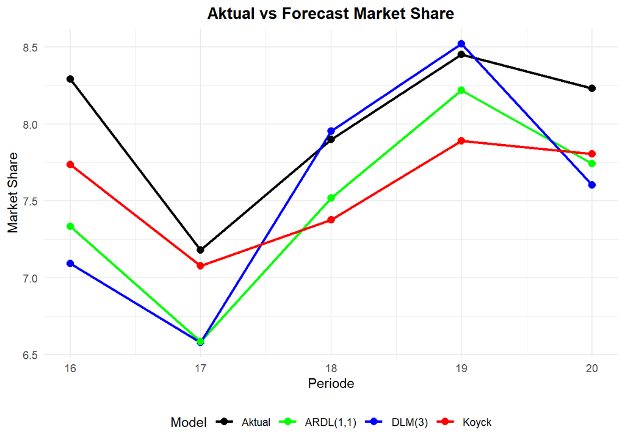

```r
library(ggplot2)

grafik <- rbind(
  data.frame(
    Periode = 16:20,
    Nilai = hasil.forecast$Aktual,
    Model = "Aktual"
  ),
  data.frame(
    Periode = 16:20,
    Nilai = hasil.forecast$Koyck,
    Model = "Koyck"
  ),
  data.frame(
    Periode = 16:20,
    Nilai = hasil.forecast$DLM,
    Model = "DLM(3)"
  ),
  data.frame(
    Periode = 16:20,
    Nilai = hasil.forecast$ARDL,
    Model = "ARDL(1,1)"
  )
)

ggplot(grafik, aes(x = Periode, y = Nilai, color = Model)) +
  geom_line(linewidth = 1) +
  geom_point(size = 2.5) +
  scale_color_manual(
    values = c(
      "Aktual" = "black",
      "Koyck" = "red",
      "DLM(3)" = "blue",
      "ARDL(1,1)" = "green"
    )
  ) +
  labs(
    title = "Aktual vs Forecast Market Share",
    x = "Periode",
    y = "Market Share",
    color = "Model"
  ) +
  theme_minimal() +
  theme(
    plot.title = element_text(
      hjust = 0.5,
      face = "bold"
    ),
    legend.position = "bottom"
  )
```

Berdasarkan AIC dan BIC, DLM(3) merupakan model terbaik karena memiliki nilai AIC sebesar 14,4199 dan BIC sebesar 17,3293, yang merupakan nilai terendah dibandingkan model Koyck dan ARDL(1,1). Namun, berdasarkan evaluasi kemampuan forecasting menggunakan data testing, model Koyck memberikan performa terbaik karena menghasilkan nilai RMSE sebesar 0,4666 dan MAE sebesar 0,4336, yang merupakan nilai terkecil. Oleh karena itu, apabila kriteria utama adalah akurasi peramalan, model Koyck dipilih sebagai model terbaik.

# Soal nomor 2

```r
data <- data.frame(
  Year = 1975:2014,
  Sales = c(
    11.7, 12.2, 12.3, 12.8, 13.1, 13.6, 13.9, 14.4,
    14.7, 15.3, 15.5, 15.8, 16.1, 16.6, 16.9, 16.7,
    16.9, 17.4, 17.6, 17.9, 18.0, 17.9, 18.0, 18.2,
    18.2, 18.3, 18.6, 19.2, 19.3, 19.5, 19.2, 19.3,
    19.5, 20.0, 20.0, 19.9, 19.8, 19.9, 20.2, 21.0
  ),
  Advertising = c(
    9.4, 9.6, 10.0, 10.4, 10.8, 10.9, 11.7, 12.2,
    12.5, 12.9, 13.0, 13.2, 13.8, 14.2, 14.6, 14.4,
    15.0, 15.4, 15.7, 15.9, 15.9, 16.0, 16.3, 16.2,
    16.8, 17.3, 17.6, 18.1, 18.3, 18.5, 18.7, 18.9,
    19.2, 20.0, 20.0, 20.3, 20.4, 21.0, 21.5, 22.1
  )
)
```

```r
library(tseries)

adf.test(data$Sales)
```

```
##
##  Augmented Dickey-Fuller Test
##
## data:  data$Sales
## Dickey-Fuller = -2.2614, Lag order = 3, p-value = 0.4709
## alternative hypothesis: stationary
```

```r
adf.test(data$Advertising)
```

```
##
##  Augmented Dickey-Fuller Test
##
## data:  data$Advertising
## Dickey-Fuller = -2.2643, Lag order = 3, p-value = 0.4697
## alternative hypothesis: stationary
```

Karena $p>0.05$, Advertising juga tidak stasioner pada level.

```r
library(dLagM)

hasil_ardl <- data.frame(
  Model = character(),
  AIC = numeric(),
  BIC = numeric(),
  stringsAsFactors = FALSE
)

for (p in 1:5) {
  for (q in 1:5) {

    model <- ardlDlm(
      formula = Sales ~ Advertising,
      data = data,
      p = p,
      q = q
    )

    hasil_ardl <- rbind(
      hasil_ardl,
      data.frame(
        Model = paste0("ARDL(", p, ",", q, ")"),
        AIC = AIC(model$model),
        BIC = BIC(model$model)
      )
    )
  }
}

hasil_ardl <- hasil_ardl[order(hasil_ardl$AIC), ]

hasil_ardl
```

```
##        Model        AIC        BIC
## 11 ARDL(3,1) -15.307592 -4.0311667
## 6  ARDL(2,1) -14.483896 -4.6583790
## 12 ARDL(3,2) -13.792624 -0.9052802
## 19 ARDL(4,4) -13.467396  3.9513120
## 9  ARDL(2,4) -13.009422  1.2422481
## 7  ARDL(2,2) -12.585015 -1.1219117
## 14 ARDL(3,4) -12.316542  3.5186469
## 8  ARDL(2,3) -12.032563  0.8547804
## 13 ARDL(3,3) -11.928489  2.5697724
## 4  ARDL(1,4) -11.863121  0.8050302
## 16 ARDL(4,1) -11.594513  1.0736383
## 24 ARDL(5,4) -11.059153  7.6050241
## 20 ARDL(4,5) -10.947559  7.7166178
## 10 ARDL(2,5) -10.665301  4.8881800
## 1  ARDL(1,1) -10.442880 -2.1250715
## 15 ARDL(3,5) -10.148190  6.9606385
## 17 ARDL(4,2) -10.116329  4.1353419
## 5  ARDL(1,5) -10.084439  3.9136933
## 21 ARDL(5,1)  -9.986040  4.0120921
## 3  ARDL(1,3)  -9.513522  1.7629037
## 25 ARDL(5,5)  -9.143559 11.0759654
## 18 ARDL(4,3)  -8.505244  7.3299453
## 22 ARDL(5,2)  -8.119891  7.4335892
## 2  ARDL(1,2)  -7.961140  1.8643773
## 23 ARDL(5,3)  -6.654795 10.4540341
```

Karena AIC terkecil adalah -15.30759, maka: ARDL (3,1)

```r
model_ardl <- ardlDlm(
  formula = Sales ~ Advertising,
  data = data,
  p = 1,
  q = 3
)

summary(model_ardl)
```

```
##
## Time series regression with "ts" data:
## Start = 4, End = 40
##
## Call:
## dynlm(formula = as.formula(model.text), data = data)
##
## Residuals:
##      Min       1Q   Median       3Q      Max
## -0.37258 -0.10816 -0.00532  0.12191  0.36434
##
## Coefficients:
##                Estimate Std. Error t value Pr(>|t|)
## (Intercept)    1.419884   0.515268   2.756  0.00972 **
## Advertising.t  0.397577   0.147397   2.697  0.01120 *
## Advertising.1 -0.295260   0.166321  -1.775  0.08568 .
## Sales.1        1.003329   0.174434   5.752 2.49e-06 ***
## Sales.2       -0.171331   0.228866  -0.749  0.45974
## Sales.3       -0.004058   0.165206  -0.025  0.98056
## ---
## Signif. codes:  0 '***' 0.001 '**' 0.01 '*' 0.05 '.' 0.1 ' ' 1
##
## Residual standard error: 0.1924 on 31 degrees of freedom
## Multiple R-squared:  0.9935, Adjusted R-squared:  0.9924
## F-statistic: 942.8 on 5 and 31 DF,  p-value: < 2.2e-16
```

Advertising saat ini

Koefisien:

Artinya Advertising pada periode sekarang berpengaruh positif dan signifikan terhadap Sales.

Dengan kata lain, kenaikan Advertising pada periode sekarang berkaitan dengan peningkatan Sales sekitar 0,482 satuan, dengan asumsi komponen lain dalam model tetap.

Advertising lag

Artinya, Advertising pada periode sebelumnya belum menunjukkan pengaruh yang signifikan secara individual terhadap Sales.

Sales lag 1

Koefisien:

dengan $p<0.001$.

Artinya Sales periode sebelumnya berpengaruh positif dan sangat signifikan terhadap Sales periode sekarang.

Hal ini menunjukkan bahwa Sales memiliki persistensi yang kuat dari waktu ke waktu.

```r
coef(model_ardl$model)
```

```
##   (Intercept) Advertising.t Advertising.1       Sales.1       Sales.2
##   1.419884127   0.397577322  -0.295260174   1.003328768  -0.171330680
##       Sales.3
##  -0.004057944
```

```r
summary(model_ardl$model)
```

```
##
## Time series regression with "ts" data:
## Start = 4, End = 40
##
## Call:
## dynlm(formula = as.formula(model.text), data = data)
##
## Residuals:
##      Min       1Q   Median       3Q      Max
## -0.37258 -0.10816 -0.00532  0.12191  0.36434
##
## Coefficients:
##                Estimate Std. Error t value Pr(>|t|)
## (Intercept)    1.419884   0.515268   2.756  0.00972 **
## Advertising.t  0.397577   0.147397   2.697  0.01120 *
## Advertising.1 -0.295260   0.166321  -1.775  0.08568 .
## Sales.1        1.003329   0.174434   5.752 2.49e-06 ***
## Sales.2       -0.171331   0.228866  -0.749  0.45974
## Sales.3       -0.004058   0.165206  -0.025  0.98056
## ---
## Signif. codes:  0 '***' 0.001 '**' 0.01 '*' 0.05 '.' 0.1 ' ' 1
##
## Residual standard error: 0.1924 on 31 degrees of freedom
## Multiple R-squared:  0.9935, Adjusted R-squared:  0.9924
## F-statistic: 942.8 on 5 and 31 DF,  p-value: < 2.2e-16
```

```r
head(hasil_ardl, 10)
```

```
##        Model       AIC        BIC
## 11 ARDL(3,1) -15.30759 -4.0311667
## 6  ARDL(2,1) -14.48390 -4.6583790
## 12 ARDL(3,2) -13.79262 -0.9052802
## 19 ARDL(4,4) -13.46740  3.9513120
## 9  ARDL(2,4) -13.00942  1.2422481
## 7  ARDL(2,2) -12.58501 -1.1219117
## 14 ARDL(3,4) -12.31654  3.5186469
## 8  ARDL(2,3) -12.03256  0.8547804
## 13 ARDL(3,3) -11.92849  2.5697724
## 4  ARDL(1,4) -11.86312  0.8050302
```

```r
library(lmtest)

dwtest(model_ardl$model)
```

```
##
##  Durbin-Watson test
##
## data:  model_ardl$model
## DW = 2.0836, p-value = 0.4684
## alternative hypothesis: true autocorrelation is greater than 0
```

```r
library(lmtest)
```

```r
bgtest(model_ardl$model)
```

```
##
##  Breusch-Godfrey test for serial correlation of order up to 1
##
## data:  model_ardl$model
## LM test = 1.8069, df = 1, p-value = 0.1789
```

```r
# 1. Autokorelasi - Breusch-Godfrey
lmtest::bgtest(model_ardl$model)
```

```
##
##  Breusch-Godfrey test for serial correlation of order up to 1
##
## data:  model_ardl$model
## LM test = 1.8069, df = 1, p-value = 0.1789
```

```r
# 2. Autokorelasi - Durbin Watson
lmtest::dwtest(model_ardl$model)
```

```
##
##  Durbin-Watson test
##
## data:  model_ardl$model
## DW = 2.0836, p-value = 0.4684
## alternative hypothesis: true autocorrelation is greater than 0
```

```r
# 3. Heteroskedastisitas - Breusch-Pagan
lmtest::bptest(model_ardl$model)
```

```
##
##  studentized Breusch-Pagan test
##
## data:  model_ardl$model
## BP = 4.6456, df = 5, p-value = 0.4606
```

```r
# 4. Normalitas residual
shapiro.test(residuals(model_ardl$model))
```

```
##
##  Shapiro-Wilk normality test
##
## data:  residuals(model_ardl$model)
## W = 0.98846, p-value = 0.9616
```

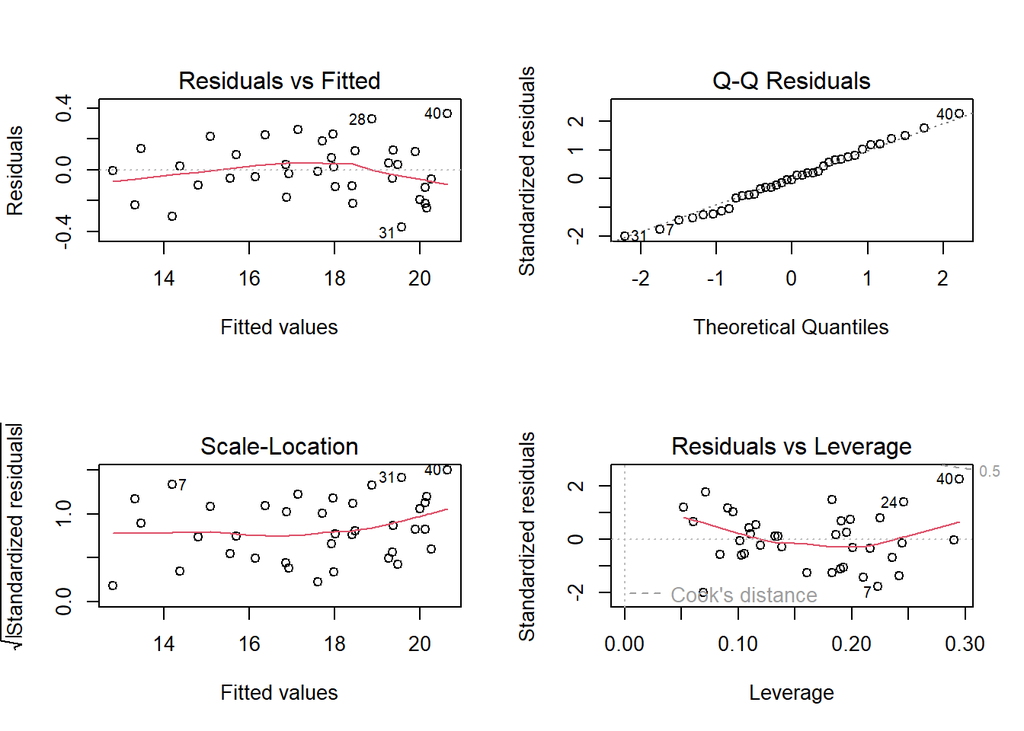

```r
par(mfrow = c(2,2))

plot(model_ardl$model)
```

```r
# Cek jumlah observasi
nrow(data)
```

```
## [1] 40
```

```r
# Cek missing value
sum(is.na(data$Sales))
```

```
## [1] 0
```

```r
sum(is.na(data$Advertising))
```

```
## [1] 0
```

# Sales

```r
library(urca)

adf_sales_level <- ur.df(
  data$Sales,
  type = "drift",
  lags = 1
)

summary(adf_sales_level)
```

```
##
## ###############################################
## # Augmented Dickey-Fuller Test Unit Root Test #
## ###############################################
##
## Test regression drift
##
##
## Call:
## lm(formula = z.diff ~ z.lag.1 + 1 + z.diff.lag)
##
## Residuals:
##      Min       1Q   Median       3Q      Max
## -0.46006 -0.11295 -0.01796  0.12782  0.65246
##
## Coefficients:
##             Estimate Std. Error t value Pr(>|t|)
## (Intercept)  0.72665    0.32117   2.262   0.0300 *
## z.lag.1     -0.02992    0.01739  -1.720   0.0942 .
## z.diff.lag   0.08428    0.18740   0.450   0.6557
## ---
## Signif. codes:  0 '***' 0.001 '**' 0.01 '*' 0.05 '.' 0.1 ' ' 1
##
## Residual standard error: 0.2301 on 35 degrees of freedom
## Multiple R-squared:  0.1181, Adjusted R-squared:  0.06776
## F-statistic: 2.345 on 2 and 35 DF,  p-value: 0.1108
##
##
## Value of test-statistic is: -1.7202 7.3234
##
## Critical values for test statistics:
##       1pct  5pct 10pct
## tau2 -3.58 -2.93 -2.60
## phi1  7.06  4.86  3.94
```

# Advertising

```r
adf_adv_level <- ur.df(
  data$Advertising,
  type = "drift",
  lags = 1
)

summary(adf_adv_level)
```

```
##
## ###############################################
## # Augmented Dickey-Fuller Test Unit Root Test #
## ###############################################
##
## Test regression drift
##
##
## Call:
## lm(formula = z.diff ~ z.lag.1 + 1 + z.diff.lag)
##
## Residuals:
##      Min       1Q   Median       3Q      Max
## -0.52232 -0.13515 -0.00909  0.19425  0.48044
##
## Coefficients:
##              Estimate Std. Error t value Pr(>|t|)
## (Intercept)  0.422385   0.192990   2.189   0.0354 *
## z.lag.1     -0.003367   0.011493  -0.293   0.7713
## z.diff.lag  -0.127253   0.170194  -0.748   0.4596
## ---
## Signif. codes:  0 '***' 0.001 '**' 0.01 '*' 0.05 '.' 0.1 ' ' 1
##
## Residual standard error: 0.2344 on 35 degrees of freedom
## Multiple R-squared:  0.01795,    Adjusted R-squared:  -0.03817
## F-statistic: 0.3198 on 2 and 35 DF,  p-value: 0.7284
##
##
## Value of test-statistic is: -0.293 15.6012
##
## Critical values for test statistics:
##       1pct  5pct 10pct
## tau2 -3.58 -2.93 -2.60
## phi1  7.06  4.86  3.94
```

## Uji ADF pada first difference

# Sales

```r
adf_sales_diff <- ur.df(
  diff(data$Sales),
  type = "drift",
  lags = 1
)

summary(adf_sales_diff)
```

```
##
## ###############################################
## # Augmented Dickey-Fuller Test Unit Root Test #
## ###############################################
##
## Test regression drift
##
##
## Call:
## lm(formula = z.diff ~ z.lag.1 + 1 + z.diff.lag)
##
## Residuals:
##      Min       1Q   Median       3Q      Max
## -0.53043 -0.13245 -0.00620  0.09582  0.54431
##
## Coefficients:
##              Estimate Std. Error t value Pr(>|t|)
## (Intercept)  0.179423   0.064204   2.795  0.00848 **
## z.lag.1     -0.742455   0.230976  -3.214  0.00286 **
## z.diff.lag  -0.004992   0.181122  -0.028  0.97817
## ---
## Signif. codes:  0 '***' 0.001 '**' 0.01 '*' 0.05 '.' 0.1 ' ' 1
##
## Residual standard error: 0.2407 on 34 degrees of freedom
## Multiple R-squared:  0.3336, Adjusted R-squared:  0.2944
## F-statistic: 8.509 on 2 and 34 DF,  p-value: 0.001009
##
##
## Value of test-statistic is: -3.2144 5.2578
##
## Critical values for test statistics:
##       1pct  5pct 10pct
## tau2 -3.58 -2.93 -2.60
## phi1  7.06  4.86  3.94
```

# Advertising

```r
adf_adv_diff <- ur.df(
  diff(data$Advertising),
  type = "drift",
  lags = 1
)

summary(adf_adv_diff)
```

```
##
## ###############################################
## # Augmented Dickey-Fuller Test Unit Root Test #
## ###############################################
##
## Test regression drift
##
##
## Call:
## lm(formula = z.diff ~ z.lag.1 + 1 + z.diff.lag)
##
## Residuals:
##      Min       1Q   Median       3Q      Max
## -0.51471 -0.14558  0.00343  0.19718  0.46715
##
## Coefficients:
##             Estimate Std. Error t value Pr(>|t|)
## (Intercept)  0.37644    0.09349   4.027 0.000300 ***
## z.lag.1     -1.15432    0.26740  -4.317 0.000129 ***
## z.diff.lag   0.02711    0.17637   0.154 0.878758
## ---
## Signif. codes:  0 '***' 0.001 '**' 0.01 '*' 0.05 '.' 0.1 ' ' 1
##
## Residual standard error: 0.2378 on 34 degrees of freedom
## Multiple R-squared:  0.5526, Adjusted R-squared:  0.5263
## F-statistic:    21 on 2 and 34 DF,  p-value: 1.151e-06
##
##
## Value of test-statistic is: -4.3168 9.3495
##
## Critical values for test statistics:
##       1pct  5pct 10pct
## tau2 -3.58 -2.93 -2.60
## phi1  7.06  4.86  3.94
```

# Pemilihan lag ARDL

```r
# Aktifkan package
library(dLagM)
```

```r
ardlDlm
```

```
## function (formula = NULL, data = NULL, x = NULL, y = NULL, p = 1,
##     q = 1, remove = NULL, type = NULL)
## UseMethod("ardlDlm")
## <bytecode: 0x00000277afb9ae40>
## <environment: namespace:dLagM>
```

```r
model <- ardlDlm(
  formula = Sales ~ Advertising,
  data = data,
  p = 1,
  q = 3
)

summary(model)
```

```
##
## Time series regression with "ts" data:
## Start = 4, End = 40
##
## Call:
## dynlm(formula = as.formula(model.text), data = data)
##
## Residuals:
##      Min       1Q   Median       3Q      Max
## -0.37258 -0.10816 -0.00532  0.12191  0.36434
##
## Coefficients:
##                Estimate Std. Error t value Pr(>|t|)
## (Intercept)    1.419884   0.515268   2.756  0.00972 **
## Advertising.t  0.397577   0.147397   2.697  0.01120 *
## Advertising.1 -0.295260   0.166321  -1.775  0.08568 .
## Sales.1        1.003329   0.174434   5.752 2.49e-06 ***
## Sales.2       -0.171331   0.228866  -0.749  0.45974
## Sales.3       -0.004058   0.165206  -0.025  0.98056
## ---
## Signif. codes:  0 '***' 0.001 '**' 0.01 '*' 0.05 '.' 0.1 ' ' 1
##
## Residual standard error: 0.1924 on 31 degrees of freedom
## Multiple R-squared:  0.9935, Adjusted R-squared:  0.9924
## F-statistic: 942.8 on 5 and 31 DF,  p-value: < 2.2e-16
```

```r
exists("ardlDlm")
```

```
## [1] TRUE
```

```r
hasil_ardl <- data.frame(
  Model = character(),
  AIC = numeric(),
  BIC = numeric()
)

for (p in 1:4) {
  for (q in 1:4) {

    model <- ardlDlm(
      formula = Sales ~ Advertising,
      data = data,
      p = p,
      q = q
    )

    hasil_ardl <- rbind(
      hasil_ardl,
      data.frame(
        Model = paste0("ARDL(", p, ",", q, ")"),
        AIC = AIC(model$model),
        BIC = BIC(model$model)
      )
    )
  }
}

hasil_ardl <- hasil_ardl[order(hasil_ardl$AIC), ]

head(hasil_ardl, 10)
```

```
##        Model       AIC        BIC
## 9  ARDL(3,1) -15.30759 -4.0311667
## 5  ARDL(2,1) -14.48390 -4.6583790
## 10 ARDL(3,2) -13.79262 -0.9052802
## 16 ARDL(4,4) -13.46740  3.9513120
## 8  ARDL(2,4) -13.00942  1.2422481
## 6  ARDL(2,2) -12.58501 -1.1219117
## 12 ARDL(3,4) -12.31654  3.5186469
## 7  ARDL(2,3) -12.03256  0.8547804
## 11 ARDL(3,3) -11.92849  2.5697724
## 4  ARDL(1,4) -11.86312  0.8050302
```

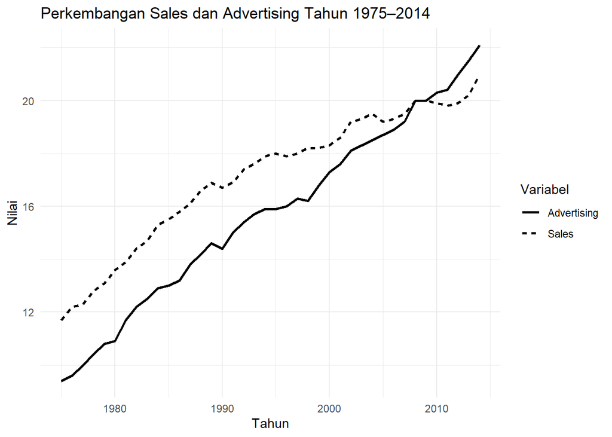

```r
library(ggplot2)

ggplot(data, aes(x = Year)) +
  geom_line(aes(y = Sales, linetype = "Sales"), linewidth = 1) +
  geom_line(aes(y = Advertising, linetype = "Advertising"), linewidth = 1) +
  labs(
    title = "Perkembangan Sales dan Advertising Tahun 1975–2014",
    x = "Tahun",
    y = "Nilai",
    linetype = "Variabel"
  ) +
  theme_minimal()
```

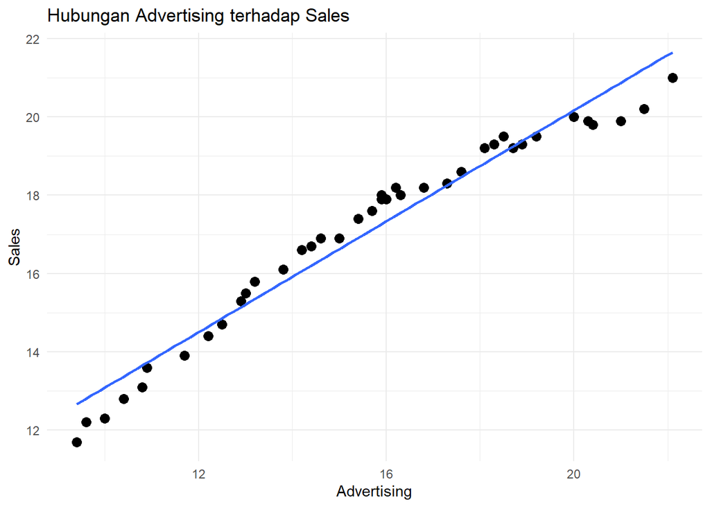

```r
ggplot(data, aes(x = Advertising, y = Sales)) +
  geom_point(size = 3) +
  geom_smooth(method = "lm", se = FALSE) +
  labs(
    title = "Hubungan Advertising terhadap Sales",
    x = "Advertising",
    y = "Sales"
  ) +
  theme_minimal()
```

```r
data_diff <- data.frame(
  Year = data$Year[-1],
  dSales = diff(data$Sales),
  dAdvertising = diff(data$Advertising)
)
```

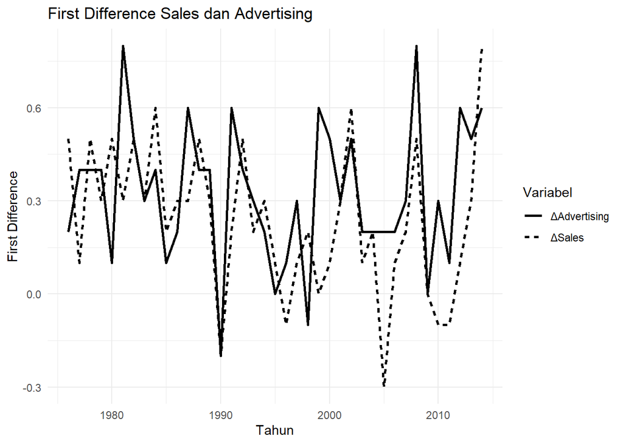

```r
ggplot(data_diff, aes(x = Year)) +
  geom_line(aes(y = dSales, linetype = "ΔSales"), linewidth = 1) +
  geom_line(aes(y = dAdvertising, linetype = "ΔAdvertising"), linewidth = 1) +
  labs(
    title = "First Difference Sales dan Advertising",
    x = "Tahun",
    y = "First Difference",
    linetype = "Variabel"
  ) +
  theme_minimal()
```

```r
hasil_ardl <- data.frame(
  Model = character(),
  p = integer(),
  q = integer(),
  AIC = numeric(),
  BIC = numeric()
)

for (p in 1:4) {
  for (q in 1:4) {

    model <- tryCatch(
      ardlDlm(
        formula = Sales ~ Advertising,
        data = data,
        p = p,
        q = q
      ),
      error = function(e) NULL
    )

    if (!is.null(model)) {

      hasil_ardl <- rbind(
        hasil_ardl,
        data.frame(
          Model = paste0("ARDL(", p, ",", q, ")"),
          p = p,
          q = q,
          AIC = AIC(model$model),
          BIC = BIC(model$model)
        )
      )
    }
  }
}

hasil_ardl <- hasil_ardl[order(hasil_ardl$AIC), ]

hasil_ardl
```

```
##        Model p q        AIC        BIC
## 9  ARDL(3,1) 3 1 -15.307592 -4.0311667
## 5  ARDL(2,1) 2 1 -14.483896 -4.6583790
## 10 ARDL(3,2) 3 2 -13.792624 -0.9052802
## 16 ARDL(4,4) 4 4 -13.467396  3.9513120
## 8  ARDL(2,4) 2 4 -13.009422  1.2422481
## 6  ARDL(2,2) 2 2 -12.585015 -1.1219117
## 12 ARDL(3,4) 3 4 -12.316542  3.5186469
## 7  ARDL(2,3) 2 3 -12.032563  0.8547804
## 11 ARDL(3,3) 3 3 -11.928489  2.5697724
## 4  ARDL(1,4) 1 4 -11.863121  0.8050302
## 13 ARDL(4,1) 4 1 -11.594513  1.0736383
## 1  ARDL(1,1) 1 1 -10.442880 -2.1250715
## 14 ARDL(4,2) 4 2 -10.116329  4.1353419
## 3  ARDL(1,3) 1 3  -9.513522  1.7629037
## 15 ARDL(4,3) 4 3  -8.505244  7.3299453
## 2  ARDL(1,2) 1 2  -7.961140  1.8643773
```

```r
hasil_ardl
```

```
##        Model p q        AIC        BIC
## 9  ARDL(3,1) 3 1 -15.307592 -4.0311667
## 5  ARDL(2,1) 2 1 -14.483896 -4.6583790
## 10 ARDL(3,2) 3 2 -13.792624 -0.9052802
## 16 ARDL(4,4) 4 4 -13.467396  3.9513120
## 8  ARDL(2,4) 2 4 -13.009422  1.2422481
## 6  ARDL(2,2) 2 2 -12.585015 -1.1219117
## 12 ARDL(3,4) 3 4 -12.316542  3.5186469
## 7  ARDL(2,3) 2 3 -12.032563  0.8547804
## 11 ARDL(3,3) 3 3 -11.928489  2.5697724
## 4  ARDL(1,4) 1 4 -11.863121  0.8050302
## 13 ARDL(4,1) 4 1 -11.594513  1.0736383
## 1  ARDL(1,1) 1 1 -10.442880 -2.1250715
## 14 ARDL(4,2) 4 2 -10.116329  4.1353419
## 3  ARDL(1,3) 1 3  -9.513522  1.7629037
## 15 ARDL(4,3) 4 3  -8.505244  7.3299453
## 2  ARDL(1,2) 1 2  -7.961140  1.8643773
```

```r
p_best <- hasil_ardl$p[1]
q_best <- hasil_ardl$q[1]

p_best
```

```
## [1] 3
```

```r
q_best
```

```
## [1] 1
```

# Model Terbaik

```r
model_terbaik <- ardlDlm(
  formula = Sales ~ Advertising,
  data = data,
  p = p_best,
  q = q_best
)
```

```r
summary(model_terbaik)
```

```
##
## Time series regression with "ts" data:
## Start = 4, End = 40
##
## Call:
## dynlm(formula = as.formula(model.text), data = data)
##
## Residuals:
##      Min       1Q   Median       3Q      Max
## -0.32655 -0.14100 -0.00725  0.12119  0.34656
##
## Coefficients:
##               Estimate Std. Error t value Pr(>|t|)
## (Intercept)    0.78590    0.53928   1.457  0.15509
## Advertising.t  0.48221    0.13836   3.485  0.00149 **
## Advertising.1 -0.06545    0.17642  -0.371  0.71316
## Advertising.2 -0.22895    0.17636  -1.298  0.20380
## Advertising.3 -0.14605    0.13469  -1.084  0.28658
## Sales.1        0.91115    0.07235  12.594 9.95e-14 ***
## ---
## Signif. codes:  0 '***' 0.001 '**' 0.01 '*' 0.05 '.' 0.1 ' ' 1
##
## Residual standard error: 0.1779 on 31 degrees of freedom
## Multiple R-squared:  0.9944, Adjusted R-squared:  0.9935
## F-statistic:  1104 on 5 and 31 DF,  p-value: < 2.2e-16
```

```r
AIC(model_terbaik$model)
```

```
## [1] -15.30759
```

```r
BIC(model_terbaik$model)
```

```
## [1] -4.031167
```

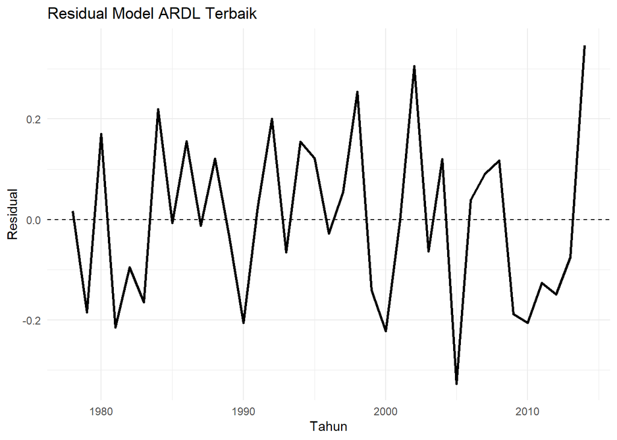

```r
res <- residuals(model_terbaik$model)

data_res <- data.frame(
  Year = tail(data$Year, length(res)),
  Residual = as.numeric(res)
)

ggplot(data_res, aes(x = Year, y = Residual)) +
  geom_line(linewidth = 1) +
  geom_hline(yintercept = 0, linetype = "dashed") +
  labs(
    title = "Residual Model ARDL Terbaik",
    x = "Tahun",
    y = "Residual"
  ) +
  theme_minimal()
```

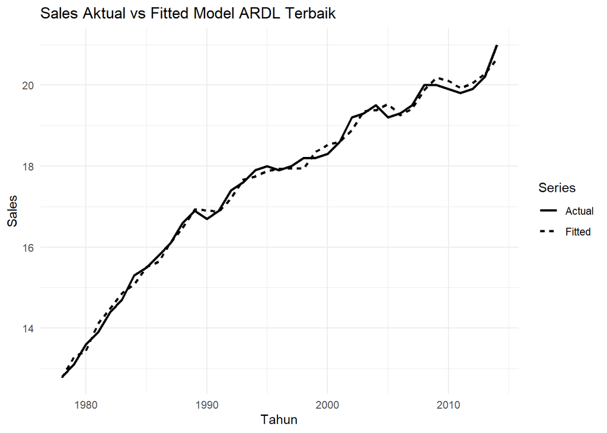

```r
fitted <- fitted(model_terbaik$model)

data_fit <- data.frame(
  Year = tail(data$Year, length(fitted)),
  Actual = tail(data$Sales, length(fitted)),
  Fitted = as.numeric(fitted)
)

ggplot(data_fit, aes(x = Year)) +
  geom_line(aes(y = Actual, linetype = "Actual"), linewidth = 1) +
  geom_line(aes(y = Fitted, linetype = "Fitted"), linewidth = 1) +
  labs(
    title = "Sales Aktual vs Fitted Model ARDL Terbaik",
    x = "Tahun",
    y = "Sales",
    linetype = "Series"
  ) +
  theme_minimal()
```